# Project Python Foundations: FoodHub Data Analysis

**Marks: 60**

### Context

The number of restaurants in New York is increasing day by day. Lots of students and busy professionals rely on those restaurants due to their hectic lifestyles. Online food delivery service is a great option for them. It provides them with good food from their favorite restaurants. A food aggregator company FoodHub offers access to multiple restaurants through a single smartphone app.

The app allows the restaurants to receive a direct online order from a customer. The app assigns a delivery person from the company to pick up the order after it is confirmed by the restaurant. The delivery person then uses the map to reach the restaurant and waits for the food package. Once the food package is handed over to the delivery person, he/she confirms the pick-up in the app and travels to the customer's location to deliver the food. The delivery person confirms the drop-off in the app after delivering the food package to the customer. The customer can rate the order in the app. The food aggregator earns money by collecting a fixed margin of the delivery order from the restaurants.

### Objective

The food aggregator company has stored the data of the different orders made by the registered customers in their online portal. They want to analyze the data to get a fair idea about the demand of different restaurants which will help them in enhancing their customer experience. Suppose you are hired as a Data Scientist in this company and the Data Science team has shared some of the key questions that need to be answered. Perform the data analysis to find answers to these questions that will help the company to improve the business.

### Data Description

The data contains the different data related to a food order. The detailed data dictionary is given below.

### Data Dictionary

- order_id: Unique ID of the order
- customer_id: ID of the customer who ordered the food
- restaurant_name: Name of the restaurant
- cuisine_type: Cuisine ordered by the customer
- cost: Cost of the order
- day_of_the_week: Indicates whether the order is placed on a weekday or weekend (The weekday is from Monday to Friday and the weekend is Saturday and Sunday)
- rating: Rating given by the customer out of 5
- food_preparation_time: Time (in minutes) taken by the restaurant to prepare the food. This is calculated by taking the difference between the timestamps of the restaurant's order confirmation and the delivery person's pick-up confirmation.
- delivery_time: Time (in minutes) taken by the delivery person to deliver the food package. This is calculated by taking the difference between the timestamps of the delivery person's pick-up confirmation and drop-off information

### Let us start by importing the required libraries

```python
# import libraries for data manipulation
import numpy as np
import pandas as pd

# import libraries for data visualization
import matplotlib.pyplot as plt
import seaborn as sns
```

### Understanding the structure of the data

```python
# uncomment and run the following lines for Google Colab
from google.colab import drive
drive.mount('/content/drive')
```

```python
import warnings

# Suppress font-related warnings
warnings.filterwarnings("ignore", category=UserWarning, module="matplotlib.font_manager")
```

```python
# read the data
df = pd.read_csv('/content/drive/MyDrive/foodhub_order.csv')
# returns the first 5 rows
df.head()
```

|  | order_id | customer_id | restaurant_name | cuisine_type | cost_of_the_order | day_of_the_week | rating | food_preparation_time | delivery_time |
| --- | --- | --- | --- | --- | --- | --- | --- | --- | --- |
| 0 | 1477147 | 337525 | Hangawi | Korean | 30.75 | Weekend | Not given | 25 | 20 |
| 1 | 1477685 | 358141 | Blue Ribbon Sushi Izakaya | Japanese | 12.08 | Weekend | Not given | 25 | 23 |
| 2 | 1477070 | 66393 | Cafe Habana | Mexican | 12.23 | Weekday | 5 | 23 | 28 |
| 3 | 1477334 | 106968 | Blue Ribbon Fried Chicken | American | 29.20 | Weekend | 3 | 25 | 15 |
| 4 | 1478249 | 76942 | Dirty Bird to Go | American | 11.59 | Weekday | 4 | 25 | 24 |

```python
# Create a copy of the original DataFrame
original_df = df.copy()
```

#### Observations:

The DataFrame has 9 columns as mentioned in the Data Dictionary. Data in each row corresponds to the order placed by a customer.

### **Question 1:** How many rows and columns are present in the data? [0.5 mark]

```python
# Write your code here

# Get the dimensions (number of rows and columns) of the DataFrame 'df'
df.shape
```

```
(1898, 9)
```

#### Observations:

The dataset consists of 1898 rows and 9 columns, indicating a relatively moderate-sized dataset.

### **Question 2:** What are the datatypes of the different columns in the dataset? (The info() function can be used) [0.5 mark]

```python
# Use info() to print a concise summary of the DataFrame

# Display concise summary information about the DataFrame 'df'
df.info()
```

```
<class 'pandas.core.frame.DataFrame'>
RangeIndex: 1898 entries, 0 to 1897
Data columns (total 9 columns):
 #   Column                 Non-Null Count  Dtype
---  ------                 --------------  -----
 0   order_id               1898 non-null   int64
 1   customer_id            1898 non-null   int64
 2   restaurant_name        1898 non-null   object
 3   cuisine_type           1898 non-null   object
 4   cost_of_the_order      1898 non-null   float64
 5   day_of_the_week        1898 non-null   object
 6   rating                 1898 non-null   object
 7   food_preparation_time  1898 non-null   int64
 8   delivery_time          1898 non-null   int64
dtypes: float64(1), int64(4), object(4)
memory usage: 133.6+ KB
```

#### Observations:

The 'rating' column is currently categorized as an object(Str). Considering its nature, further investigation is needed to determine if it should be represented as an integer for analysis purposes.

### **Question 3:** Are there any missing values in the data? If yes, treat them using an appropriate method. [1 mark]

```python
# Write your code here

# Count the number of missing values in each column of the DataFrame 'df'
df.isnull().sum()
```

```
order_id                 0
customer_id              0
restaurant_name          0
cuisine_type             0
cost_of_the_order        0
day_of_the_week          0
rating                   0
food_preparation_time    0
delivery_time            0
dtype: int64
```

#### Observations:

The output indicates that there are no missing values (nulls) in any of the columns across the entire dataset.

### **Question 4:** Check the statistical summary of the data. What is the minimum, average, and maximum time it takes for food to be prepared once an order is placed? [2 marks]

```python
# Write your code here

# Generate descriptive statistics of the DataFrame 'df' and transpose the result
# Round the values for better readability
df.describe().T.round()
```

|  | count | mean | std | min | 25% | 50% | 75% | max |
| --- | --- | --- | --- | --- | --- | --- | --- | --- |
| order_id | 1898.0 | 1477496.0 | 548.0 | 1476547.0 | 1477021.0 | 1477496.0 | 1477970.0 | 1478444.0 |
| customer_id | 1898.0 | 171168.0 | 113698.0 | 1311.0 | 77788.0 | 128600.0 | 270525.0 | 405334.0 |
| cost_of_the_order | 1898.0 | 16.0 | 7.0 | 4.0 | 12.0 | 14.0 | 22.0 | 35.0 |
| food_preparation_time | 1898.0 | 27.0 | 5.0 | 20.0 | 23.0 | 27.0 | 31.0 | 35.0 |
| delivery_time | 1898.0 | 24.0 | 5.0 | 15.0 | 20.0 | 25.0 | 28.0 | 33.0 |

#### Observations:

Cost of the Order:

The average cost of orders is approximately $16.50, with a standard deviation of $7.48, indicating some variability in the cost of different orders.

Food Preparation Time:

Food preparation time ranges from 20 to 35 minutes, with an average around 27.37 minutes, suggesting consistency in the time taken for food preparation.

Delivery Time:

Delivery time varies between 15 and 33 minutes, with an average of approximately 24.16 minutes, indicating a moderate range of delivery durations.

### **Question 5:** How many orders are not rated? [1 mark]

```python
# Write the code here

# Count the number of rows where the 'rating' column is 'Not given'
df[df.rating == 'Not given'].shape[0]
```

```
736
```

#### Observations:

There are 736 instances where the 'rating' column contains 'Not given,' it indicates that those particular entries lack explicit ratings from customers.

### Exploratory Data Analysis (EDA)

### Univariate Analysis

```python
# Specify a different font family
plt.rcParams['font.family'] = 'sans-serif'
```

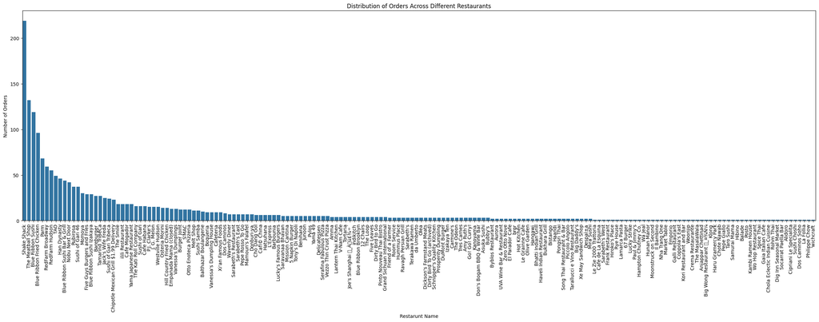

```python
# Write the code here
# 1. Restaurent Name
plt.figure(figsize=(30,8))
sns.countplot(data=df, x='restaurant_name',
              order=df['restaurant_name'].value_counts().index)
plt.xticks(rotation=90)
plt.title('Distribution of Orders Across Different Restaurants')
plt.xlabel('Restarunt Name')
plt.ylabel('Number of Orders')
plt.show();
```

OBSEVATIONS:

1. Popular restaurants stand out with higher order frequencies, showcasing varying customer preferences.
2. Diversity in choices is evident, highlighting both frequented and less popular restaurants.
3. Some restaurants have notably lower order frequencies, indicating potential outliers or areas for investigation.

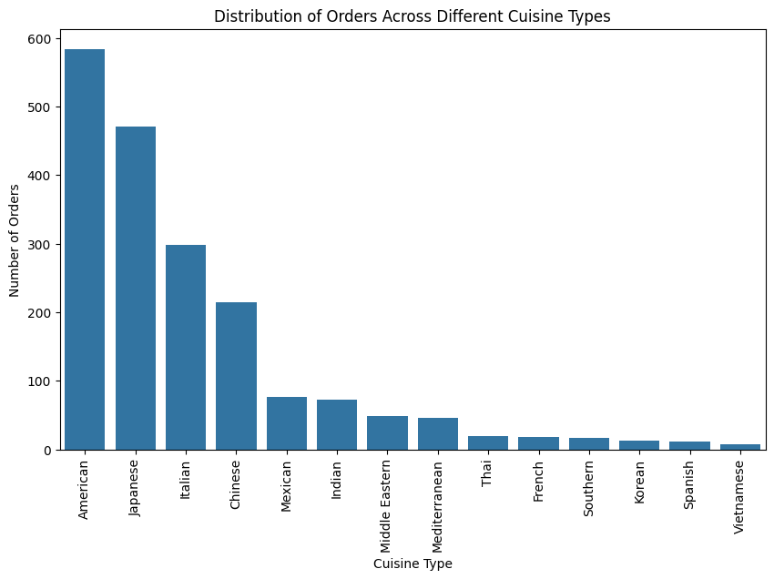

```python
# 2. Cuisine Type
plt.figure(figsize=(10, 6))
sns.countplot(data=df, x='cuisine_type',
              order=df['cuisine_type'].value_counts().index)
plt.xticks(rotation=90)
plt.title('Distribution of Orders Across Different Cuisine Types')
plt.xlabel('Cuisine Type')
plt.ylabel('Number of Orders')
plt.show()
```

OBSEVATIONS:

1. Certain cuisines, like "American" and "Japanese," stand out as popular choices, with higher order frequencies.
2. The countplot reflects a diverse range of culinary preferences, showcasing a variety of cuisine types.
3. Insights into the popularity of specific cuisines can inform strategic decisions for marketing and restaurant partnerships on the food delivery platform.

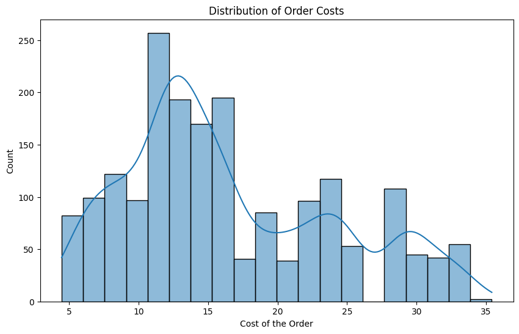

```python
# 3. cost of the order
plt.figure(figsize=(10, 6))
sns.histplot(data=df, x='cost_of_the_order', bins=20, kde=True)
plt.title('Distribution of Order Costs')
plt.xlabel('Cost of the Order')
plt.show();
```

OBSERVATIONS:

The histogram reveals a right-skewed distribution of order costs, suggesting that the majority of orders have relatively lower costs, while a smaller number of orders contribute to higher costs. This concentration around lower values may indicate a common price range for typical orders, but further investigation is needed to understand the factors contributing to the right-skewness and identify potential outliers in the higher-cost range.

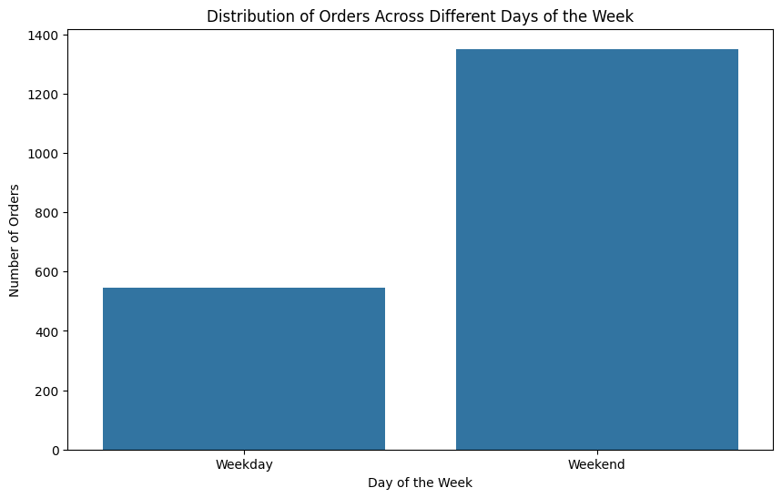

```python
# 4.Day Of The Week
plt.figure(figsize=(10,6))
sns.countplot(data=df, x='day_of_the_week',
              order=['Weekday','Weekend'])
plt.title('Distribution of Orders Across Different Days of the Week')
plt.xlabel('Day of the Week')
plt.ylabel('Number of Orders')
plt.show();
```

OBSERVATIONS:

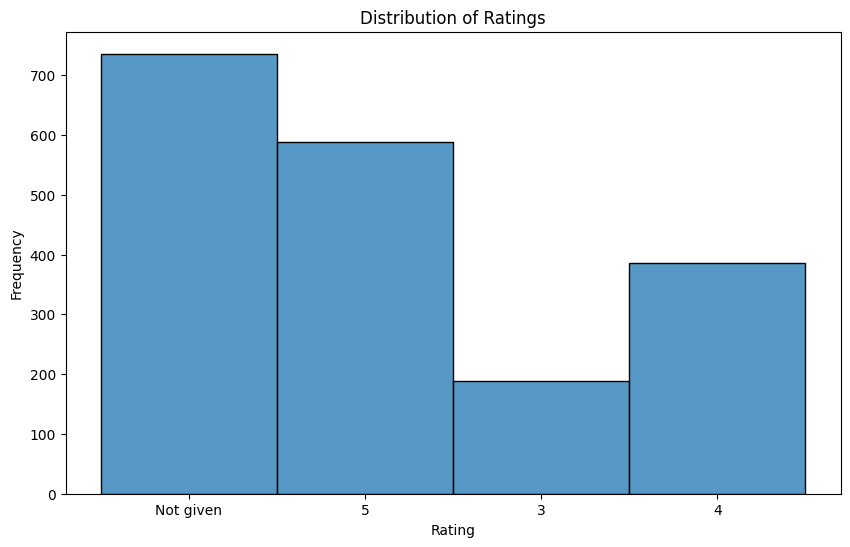

```python
# 5. Ratings

plt.figure(figsize=(10, 6))
sns.histplot(data=df, x='rating')
plt.title('Distribution of Ratings')
plt.xlabel('Rating')
plt.ylabel('Frequency')
plt.show();
```

OBSERVATIONS:

1. The majority of ratings are 5, with approximately 570 occurrences, indicating a high satisfaction level.
2. Ratings of 4 have around 400 occurrences, suggesting a significant number of positive reviews.
3. A substantial portion of the data falls into the 'Not given' category, representing values above 700, highlighting a considerable portion of missing or undefined rating information.

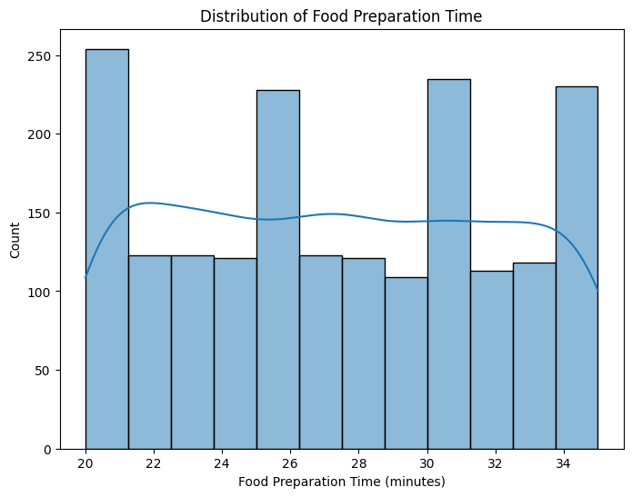

```python
plt.figure(figsize=(8, 6))

sns.histplot(data=df, x='food_preparation_time', kde=True)
plt.title('Distribution of Food Preparation Time')
plt.xlabel('Food Preparation Time (minutes)')
plt.show()
```

OBSERVATIONS:

1. Most orders (around 250) have a 20-minute food preparation time, indicating efficiency.
2. Varied preparation times: 100-150 orders in the ranges 22-24 mins, 27-29 mins, and 32-33 mins.
3. Moderate frequency (200-250 orders) for a 26-minute preparation time, slightly longer than the common 20-minute duration

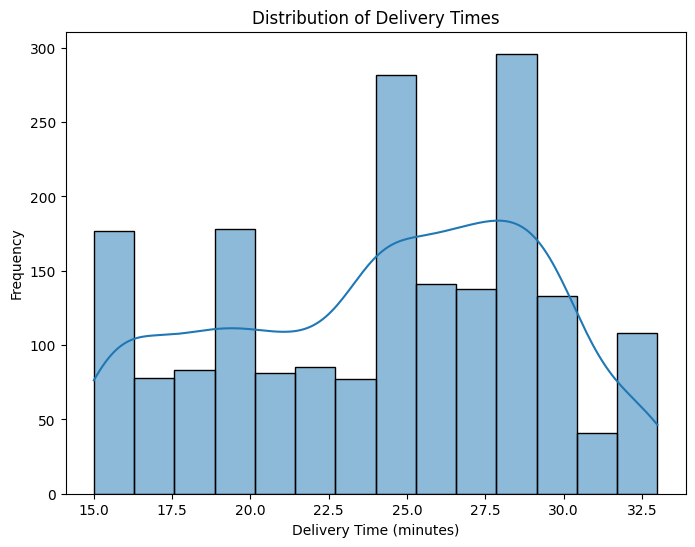

```python
plt.figure(figsize=(8, 6))

sns.histplot(data=df, x='delivery_time', kde=True)
plt.title('Distribution of Delivery Times')
plt.xlabel('Delivery Time (minutes)')
plt.ylabel('Frequency')
plt.show()
```

OBSERVATION:

1. Delivery times peak at around 28 and 25 minutes, with the highest frequency of orders
2. Shorter delivery times, like 17.5 and 22.5 minutes, still show considerable frequency, reflecting prompt service.
3. Longer delivery times, approximately 31 and 32.5 minutes, have lower frequencies, suggesting less common but still occurring instances of delayed deliveries.

### **Question 7**: Which are the top 5 restaurants in terms of the number of orders received? [1 mark]

```python
# Write the code here

# Group by 'restaurant_name' and count the unique 'order_id'
# Sort the counts in descending order and take the top 5
df.groupby('restaurant_name')\
  .order_id.nunique()\
  .sort_values(ascending=False)\
  .head(5)
```

```
restaurant_name
Shake Shack                  219
The Meatball Shop            132
Blue Ribbon Sushi            119
Blue Ribbon Fried Chicken     96
Parm                          68
Name: order_id, dtype: int64
```

#### Observations:

Shake Shack (219 orders) : Shake Shack leads with the highest order count, indicating strong customer demand.

The Meatball Shop (132 orders) : The Meatball Shop closely follows, maintaining a significant order frequency.

Blue Ribbon Sushi (119 orders) : Blue Ribbon Sushi secures the third position, showcasing substantial order engagement.

Blue Ribbon Fried Chicken (96 orders) : Blue Ribbon Fried Chicken follows, contributing prominently to the order distribution.

Parm (68 orders) : Parm completes the top 5, maintaining a notable presence in terms of order frequency.

### **Question 8**: Which is the most popular cuisine on weekends? [1 mark]

```python
# Write the code here

# Filter rows where 'day_of_the_week' is 'Weekend' and count the occurrences of each 'cuisine_type'

df[df['day_of_the_week'] == 'Weekend']['cuisine_type'].value_counts().head()
```

```
American    415
Japanese    335
Italian     207
Chinese     163
Mexican      53
Name: cuisine_type, dtype: int64
```

#### Observations:

American cuisine dominates weekends with 415 orders, indicating its popularity during that period.

### **Question 9**: What percentage of the orders cost more than 20 dollars? [2 marks]

```python
# Write the code here

# Calculate the percentage of orders with a cost greater than 20 dollars
round(df[df['cost_of_the_order'] > 20].shape[0]/df.order_id.nunique() , 2) * 100
```

```
28.999999999999996
```

#### Observations:

Approximately 29% of the orders have a cost exceeding 20 dollars, suggesting a substantial portion of orders falls into this higher-cost category.

### **Question 10**: What is the mean order delivery time? [1 mark]

```python
# Write the code here

# Calculate the mean delivery time and round the result
mean_delivert_time = df.delivery_time.mean().round()
print("The mean order delivery time is",mean_delivert_time)
```

```
The mean order delivery time is 24.0
```

#### Observations:

The mean order delivery time is 24.0, providing a central point for understanding the overall delivery time distribution.

### **Question 11:** The company has decided to give 20% discount vouchers to the top 5 most frequent customers. Find the IDs of these customers and the number of orders they placed. [1 mark]

```python
# Write the code here
# Find the top 5 most frequent customers
top_customers = df['customer_id'].value_counts().head(5)

# Filter the dataframe to include only orders from the top customers
top_customers_orders = df[df['customer_id'].isin(top_customers.index)].groupby('customer_id')['order_id'].nunique()

print("Top 5 Most Frequent Customers and Their Number of Orders:")
print(top_customers_orders)
```

```
Top 5 Most Frequent Customers and Their Number of Orders:
customer_id
47440     10
52832     13
83287      9
250494     8
259341     7
Name: order_id, dtype: int64
```

#### Observations:

The top 5 most frequent customers, identified by customer IDs (47440, 52832, 83287, 250494, 259341), placed 7 to 13 orders, showcasing their high engagement with the platform.

### **Question 12**: Perform a multivariate analysis to explore relationships between the important variables in the dataset. (It is a good idea to explore relations between numerical variables as well as relations between numerical and categorical variables) [10 marks]

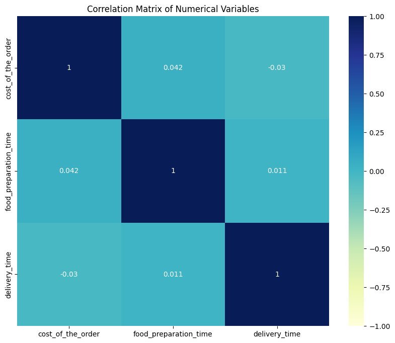

```python
# Write the code here
# 1. HeatMap for numerical columns
plt.figure(figsize=(10,8))
sns.heatmap(data = df[['cost_of_the_order','food_preparation_time','delivery_time']].corr(),annot=True, cmap='YlGnBu', vmin= -1)
plt.title('Correlation Matrix of Numerical Variables')
plt.show();
```

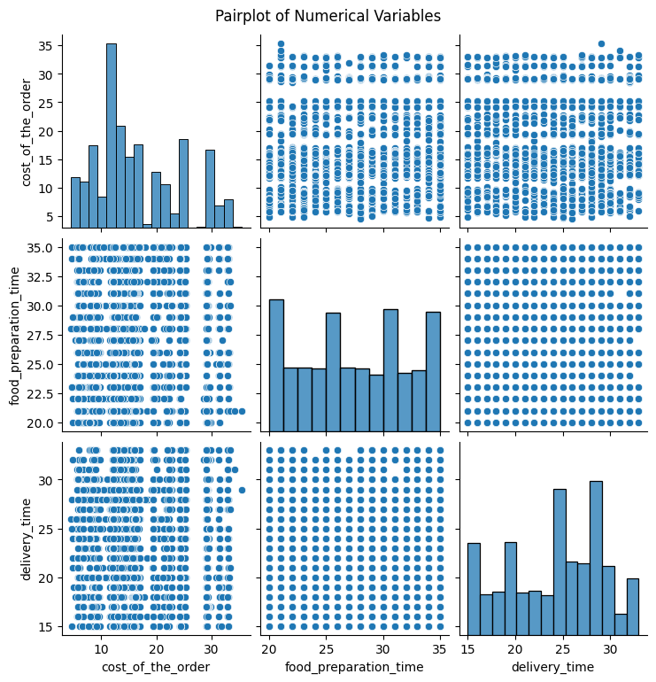

```python
# 2.PairPlot for numerical column
sns.pairplot(data=df[['cost_of_the_order','food_preparation_time','delivery_time']])
plt.suptitle('Pairplot of Numerical Variables', y=1.02)
plt.show();
```

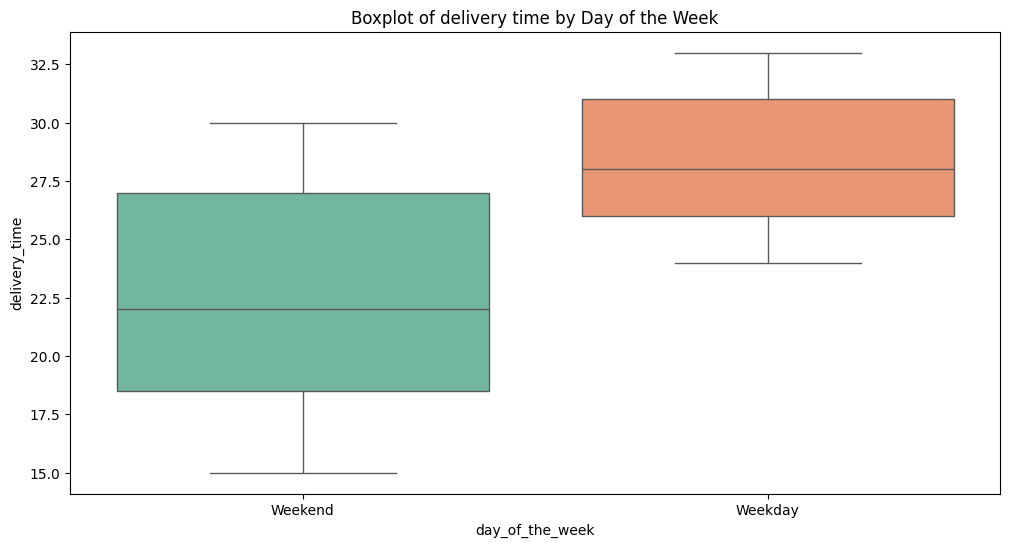

```python
# Boxplot of delivery time by Day of the Week
plt.figure(figsize=(12, 6))
sns.boxplot(x='day_of_the_week', y='delivery_time', data=df ,hue='day_of_the_week', legend=False, palette='Set2')
plt.title('Boxplot of delivery time by Day of the Week')
plt.show();
```

#### OBSERVATION:

On weekends, delivery times are concentrated between 18 and 27 minutes, with whiskers from 15 to 30 minutes.

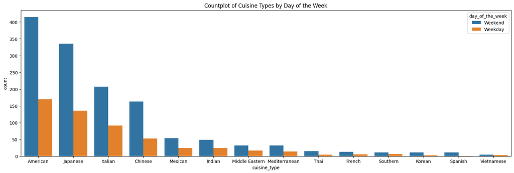

```python
plt.figure(figsize=(20, 6))
sns.countplot(data=df , x='cuisine_type', hue='day_of_the_week', order=df['cuisine_type'].value_counts().index)
plt.title('Countplot of Cuisine Types by Day of the Week')
plt.show();
```

OBSERVATIONS:

1. American cuisine has higher order counts on weekends (above 400) compared to weekdays (around 160).
2. Japanese cuisine also sees more orders on weekends (340) than weekdays (130).
3. Italian cuisine has a noticeable increase in orders on weekends (210) compared to weekdays (95).
4. Chinese cuisine experiences higher demand on weekends (160) in contrast to weekdays (50).

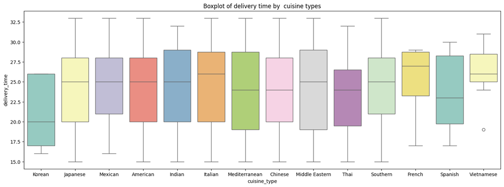

```python
plt.figure(figsize=(18, 6))
sns.boxplot(x='cuisine_type', y='delivery_time', data=df, hue='cuisine_type', palette='Set3', legend=False)
plt.title('Boxplot of delivery time by  cuisine types')
plt.show();
```

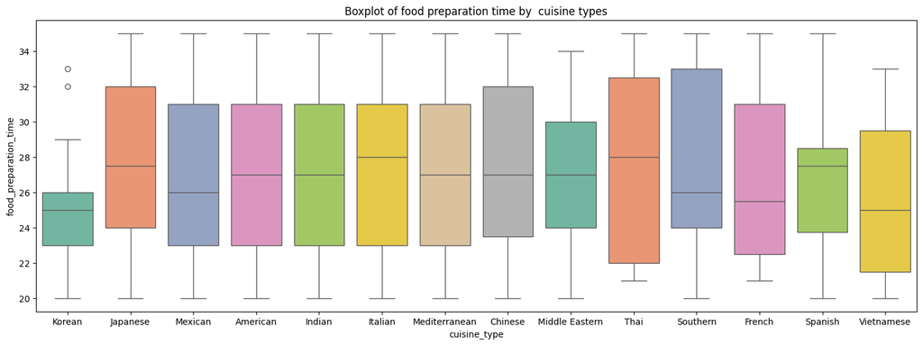

```python
plt.figure(figsize=(18, 6))
sns.boxplot(x='cuisine_type', y='food_preparation_time', data=df, hue='cuisine_type', palette='Set2', legend=False)
plt.title('Boxplot of food preparation time by  cuisine types')
plt.show();
```

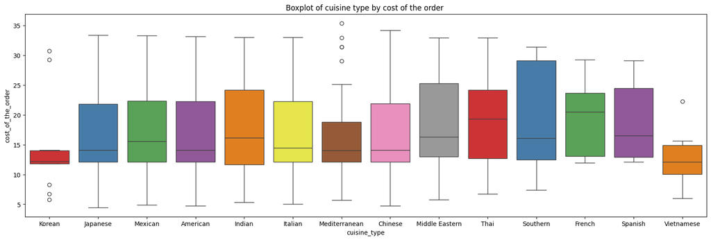

```python
plt.figure(figsize=(20, 6))
sns.boxplot(x='cuisine_type', y='cost_of_the_order', data=df, hue='cuisine_type', palette='Set1', legend=False)
plt.title('Boxplot of cuisine type by cost of the order ')
plt.show();
```

**OBSERVATIONS:**

Cost distribution varies among cuisine types, with Thai and French having higher medians, indicating expensive options, while Vietnamese and Korean show lower medians; Korean cuisine exhibits minimum outliers

### **Question 13:** The company wants to provide a promotional offer in the advertisement of the restaurants. The condition to get the offer is that the restaurants must have a rating count of more than 50 and the average rating should be greater than 4. Find the restaurants fulfilling the criteria to get the promotional offer. [3 marks]

```python
# Write the code here

# Filter out rows where rating is 'Not given' and create a copy
num_ratings = df[df['rating'] != 'Not given'].copy()
# Convert the 'rating' column to integer
num_ratings['rating'] = num_ratings['rating'].astype(int)


# Group by 'restaurant_name' and calculate mean and count of ratings
result = num_ratings.groupby(['restaurant_name'])['rating'].agg(['mean','count']).reset_index()
result[result['count'] > 50.0].sort_values(by='mean', ascending=False)
```

|  | restaurant_name | mean | count |
| --- | --- | --- | --- |
| 132 | The Meatball Shop | 4.511905 | 84 |
| 16 | Blue Ribbon Fried Chicken | 4.328125 | 64 |
| 117 | Shake Shack | 4.278195 | 133 |
| 17 | Blue Ribbon Sushi | 4.219178 | 73 |

#### Observations:

The Meatball Shop leads with the highest average rating of 4.51 among the top 4 restaurants, followed by Blue Ribbon Fried Chicken (4.33), Shake Shack (4.28), and Blue Ribbon Sushi (4.22). This suggests a generally positive customer sentiment toward these restaurants.

### **Question 14:** The company charges the restaurant 25% on the orders having cost greater than 20 dollars and 15% on the orders having cost greater than 5 dollars. Find the net revenue generated by the company across all orders. [3 marks]

```python
# Write the code here
# Calculate commission based on conditions using numpy where
# If cost_of_the_order > 20, apply 25% commission
# If cost_of_the_order > 5, apply 15% commission
# If neither condition is met, apply 0 commission

commission_rate = np.where(
    df.cost_of_the_order > 20,
    df.cost_of_the_order * 0.25,
    np.where(
        df.cost_of_the_order > 5,
        df.cost_of_the_order * 0.15,
        0
    )
).sum().round()

print(f"The net revenue generated by the company across all orders is ${commission_rate}")
```

```
The net revenue generated by the company across all orders is $6166.0
```

#### Observations:

The company's net revenue across all orders is $6166.0

### **Question 15:** The company wants to analyze the total time required to deliver the food. What percentage of orders take more than 60 minutes to get delivered from the time the order is placed? (The food has to be prepared and then delivered.) [2 marks]

```python
# Write the code here
# Calculate total time by summing delivery_time and food_preparation_time
df['total_time'] = df['delivery_time'] + df['food_preparation_time']

# Calculate percentage of orders taking more than 60 minutes
percentage = round(
    df[df.total_time > 60].shape[0]/df.shape[0],
    2
)*100

print(f"The percentage is {percentage}")
```

```
The percentage is 11.0
```

#### Observations:

Approximately 11% of orders take more than 60 minutes to be delivered from the time they are placed, indicating the proportion of orders experiencing extended preparation and delivery times.

### **Question 16:** The company wants to analyze the delivery time of the orders on weekdays and weekends. How does the mean delivery time vary during weekdays and weekends? [2 marks]

```python
# Write the code here

# Calculate the mean delivery time for Weekday and Weekend
mean_weekday = df[df['day_of_the_week'] == 'Weekday']['delivery_time'].mean().round()
mean_weekend = df[df['day_of_the_week'] == 'Weekend']['delivery_time'].mean().round()
print(f"The mean delivery time of WeekDay is {mean_weekday}")
print(f"The mean delivery time of WeekEnd is {mean_weekend}")
```

```
The mean delivery time of WeekDay is 28.0
The mean delivery time of WeekEnd is 22.0
```

#### Observations:

The mean delivery time during weekdays is 28.0, while during weekends, it reduces to 22.0. This pattern suggests that there might be a correlation between the day of the week and delivery time, potentially influenced by factors like traffic and order demand variations on different days.

### Conclusion and Recommendations

### **Question 17:** What are your conclusions from the analysis? What recommendations would you like to share to help improve the business? (You can use cuisine type and feedback ratings to drive your business recommendations.) [6 marks]

### Conclusions:

1. **Order Frequencies:**

Restaurants like Shake Shack, The Meatball Shop, Blue Ribbon Sushi, and Blue Ribbon Fried Chicken are popular, with Shake Shack having the highest order count.

1. **Cuisine Preferences:**

American cuisine is the most popular, followed by Japanese, Italian, Chinese, and Mexican. American and Japanese cuisines see increased demand on weekends.

1. **Order Costs:**

A significant percentage (around 29%) of orders cost more than 20 dollars.

1. **Delivery Times:**

The mean order delivery time is 24 minutes. Weekday deliveries have a higher mean time (28 minutes) compared to weekends (22 minutes).

1. **Customer Behavior:**

Top customers (IDs 47440, 52832, 83287, 250494, 259341) place frequent orders.

1. **Restaurant Ratings:**

The Meatball Shop has the highest average rating (4.51), followed by Blue Ribbon Fried Chicken, Shake Shack, and Blue Ribbon Sushi.

1. **Revenue Analysis:**

The company charges 25% on orders above 20 dollars and 15% on orders above 5 dollars, generating a net revenue of $6166.

1. **Delivery Time Analysis:**

About 11% of orders take more than 60 minutes to get delivered.

### Recommendations:

**Promotions**:

Promote popular cuisines like American and Japanese, especially during weekends.

**Cost Optimization:**

Encourage restaurants to offer items below 20 dollars to attract a wider customer base.

**Efficiency Improvements:**

Analyze and address the factors contributing to longer delivery times on weekdays for enhanced customer satisfaction.

**Customer Engagement:**

Consider loyalty programs or promotions to retain and reward top customers.

**Quality Focus:**

Highlight high-rated restaurants in advertisements to attract more customers.

**Revenue Maximization:**

Explore strategies to increase revenue, such as targeted pricing or partnerships.

**Customer Feedback:**

Encourage customers to provide feedback on food(reviews) and delivery times, allowing the company to identify specific pain points and areas for improvement.

**Delivery Time Optimization:**

Focus on optimizing the food preparation and delivery processes to minimize instances of extended delivery times.